# Bremer County

Welcome to the Bremer County COVID-19 Data Page.

## 2023-03-29:

53 active cases in Bremer County, IA today. If the current infection trends continue, in 4 weeks we will have 40 active cases.

In the last 7 days: 18 new positive tests, 10 new positive cases, and 0 new death(s).

If you are in a group of 30 random people in Bremer County there is a 27.31% chance someone in the group is positive. One in 282 people in Bremer County has died of COVID-19.

One year ago, we had 33 active cases and 5 new positive per day patients in Bremer County.

Two years ago, we had 85 active cases and 2 new positive per day patients in Bremer County.

In the last 7 days: 13 new positive tests, 10 new positive cases, and 0 new death(s).

One year ago, we had 30 active cases and 6 new positive per day patients in Butler County.

Two years ago, we had 31 active cases and 0 new positive per day patients in Butler County.

335 active cases in Black Hawk County, IA today. If the current infection trends continue, in 4 weeks we will have 232 active cases. If you are in a group of 30 people in Black Hawk County there is a 31.98% chance someone in the group is positive. One in 247 people in Black Hawk County has died of COVID-19.

In the last 7 days: 103 new positive tests, 58 new positive cases, and 1 new death(s).

One year ago, we had 192 active cases and 34 new positive per day patients in Black Hawk County.

Two years ago, we had 339 active cases and 17 new positive per day patients in Black Hawk County.

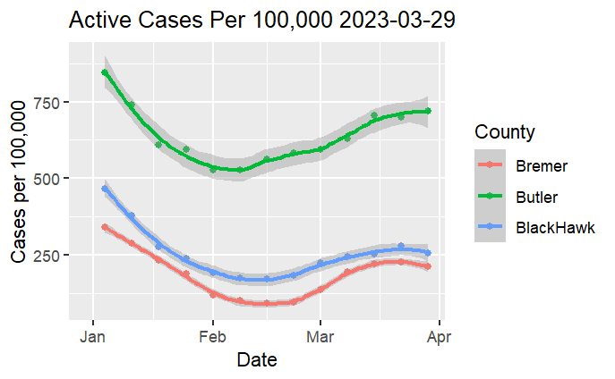

|  | 435 |
| --- | --- |
| TestedPos | 7311 |
| Positive | 6418 |
| Recovered | 6276 |
| Deaths | 89 |
| Active | 53 |
| New.Pos | 10 |
| New.Rec | 14 |
| New.Deaths | 0 |

[output not shown]

[output cut: 405 more lines]